# Introduction to citoMove

Thibault Fronville & Maximilian Pichler

March 05 2026

Abstract

‘citoMove’ allows you to prepare movement data (including biotic and abiotic interactions) and build neural networks (NN) using the ‘cito’ package

# First steps

Assuming you have citoMove installed (for instructions, see [here](https://github.com/citoverse/citoMove)), load the citoMove package via

```r
library(citoMove)
```

In case you have installation problems of citoMove, please follow the instructions given in the [cito package vignette](https://cran.r-project.org/web/packages/cito/vignettes/A-Introduction_to_cito.html)

# Example analysis using the amt::deer dataset

```r
set.seed(123)
library(amt)
library(citoMove)
library(terra)
```

The following code creates a spatial covariate: the distance to the next forest.

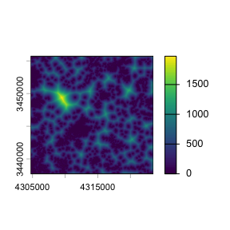

```r
forest <- amt::get_sh_forest()
forest <- terra::subst(forest, 0, NA)
forest_dist <- distance(forest)
names(forest_dist) <- "forest_dist"
plot(forest_dist)
```

Next, we load the tracking data of one red deer individual. From amt documentation: 826 GPS relocations of one red deer from northern Germany. The data is already resampled to a regular time interval of 6 hours and the coordinate reference system is transformed to epsg:3035.

The follwoing code orders the data, creates random absences, and extract the environmental predictor (distance to forest) create before for all true and random steps.

```r
dat_ssf <- amt::deer |>
  steps_by_burst() |>
  random_steps() |>
  extract_covariates(forest_dist) |>
  time_of_day() |>
  mutate(case_ = as.integer(case_))
```

Now, we can fit the deep neural network (dnn) using citoMove:

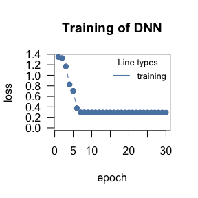

```r
model = dnn_ssf(case_ ~ forest_dist, data = dat_ssf, epoch = 30L, plot = T, verbose = FALSE)
```

The plot that is produced visualizes the improvement of the model during training. The default architecture of the neural networks entails two hidden layers. We can visualize the architecture via

```r
plot(model)
```

[output not shown]

A summary of the fitted model is provided via

```r
summary(model)
```

```
#> Summary of Deep Neural Network Model
#>
#> Feature Importance:
#>      variable importance_1
#> 1 forest_dist    0.1416872
#>
#> Average Conditional Effects:
#>              Response_1
#> forest_dist -0.07694435
#>
#> Standard Deviation of Conditional Effects:
#>             Response_1
#> forest_dist  0.1241377
```

The cito package contains several options to create effect plots. Our current recommendation is to use accumulated local effect (ALE) plots to visualize the estimated selection effects

```r
ALE(model)
```

```
#> Number of Neighborhoods reduced to 3
```

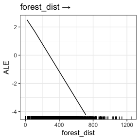